# Analysis of Mike’s polysome data

This document details the analysis of RNA-seq data from totalRNA and polysomeRNA samples of osteosarcoma cells treated with CR131B and tBHQ. Samples were ribo-depleted and sequencing on an MGI instrument.

## Setting up the environment

These are packages you will need for this notebook. For exact versions used, please refer to the session info at the bottom of this notebook.

```r
##########################################################################################
library('tidyverse')
library('RColorBrewer')
library('ggplot2')
library('tximport')
library('GenomicFeatures')
library('DESeq2')
library('org.Hs.eg.db')
library('ggrepel')
library('anota2seq')
```

I want to set a base directory that we can use as a link to the directory where we will do most of the work. I use two directories here because the Workspace is what is pushed to GitHub and contains scripts and plot files, but the Repository is where more of the big data is stored that does not get pushed.

```r
##########################################################################################
#generalDatasets = 'C:/Users/chughes/Documents/bccrc/projectsRepository/generalDatasets'
#baseWorkspace = 'C:/Users/chughes/Documents/bccrc/projectsWorkspace/sorensenLab/relatedToDlg2'
#baseRepository = 'C:/Users/chughes/Documents/bccrc/projectsRepository/sorensenLab/relatedToDlg2'
generalDatasets = 'C:/Users/chris/OneDrive/Documents/bccrc/projectsRepository/generalDatasets'
baseWorkspace = 'C:/Users/chris/OneDrive/Documents/bccrc/projectsWorkspace/sorensenLab/relatedToOthers'
baseRepository = 'C:/Users/chris/OneDrive/Documents/bccrc/projectsRepository/sorensenLab/relatedToOthers'
```

## Data processing

```r
all(file.exists(files))
```

```
[1] TRUE
```

Now import the Salmon data. I am going to process the total RNA and polysomes separately and just combine them later on downstream. First, we will do total RNA.

```r
##########################################################################################
txi = tximport(files[1:12],
               type = 'salmon',
               tx2gene = tx2gene)
```

```
reading in files with read_tsv
1 2 3 4 5 6 7 8 9 10 11 12
transcripts missing from tx2gene: 21785
summarizing abundance
summarizing counts
summarizing length
```

```r
names(txi)
```

```
[1] "abundance"           "counts"              "length"              "countsFromAbundance"
```

```r
head(txi$counts)
```

```
                       [,1]    [,2]     [,3]     [,4]     [,5]     [,6]     [,7]     [,8]     [,9]    [,10]    [,11]    [,12]
ENSG00000000003.14  404.468 237.500  482.440  388.406  387.551  304.005  417.110  384.691  476.437  646.075  387.445  339.615
ENSG00000000005.5     0.000   0.000    0.000    0.000    0.000    0.000    0.000    0.000    0.000    0.000    0.000    0.000
ENSG00000000419.12 1469.148 981.129 1618.756 1959.954 1672.029 1560.548 1522.487 1343.183 1581.527 1959.317 1638.067 1266.634
ENSG00000000457.13   85.639  53.603  114.959  159.929  157.628  134.841   77.276   94.197  140.889  209.839  144.191  136.730
ENSG00000000460.16  288.758 231.220  340.495  379.315  398.288  265.869  277.833  290.895  444.093  629.647  312.566  336.932
ENSG00000000938.12    2.000   0.000    1.000    0.000    0.000    0.000    0.000    1.001    0.000    0.000    0.000    0.000
```

Construct the DESeq2 dataset.

```r
##########################################################################################
ddsTxi = DESeqDataSetFromTximport(txi,
                                  colData = samples[1:12,],
                                  design = ~ treatment)
##
dds = DESeq(ddsTxi)
```

```
using 'avgTxLength' from assays(dds), correcting for library size
```

```r
keep = rowSums(counts(dds)) >= 150
dds = dds[keep,]
```

Perform comparisons between samples.

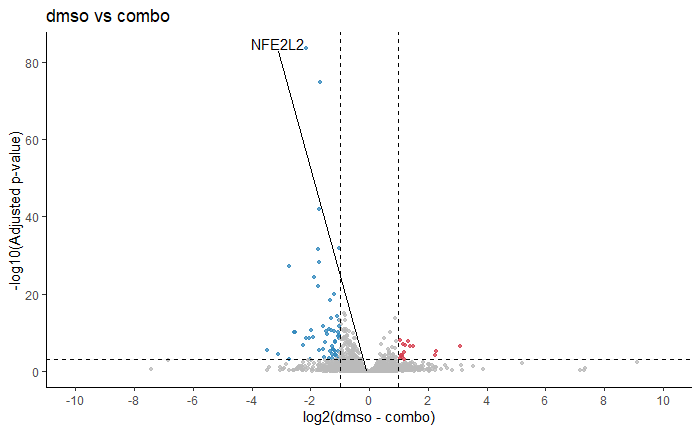

```r
##########################################################################################
datasetFirst = 'dmso'
datasetSecond = 'combo'
res = results(dds, contrast = c('treatment', datasetFirst, datasetSecond))
ens.str = substr(rownames(res), 1, 15)
res$symbol = mapIds(org.Hs.eg.db,
                     keys=ens.str,
                     column="SYMBOL",
                     keytype="ENSEMBL",
                     multiVals="first")
resOrdered = res[order(res$pvalue) & !is.na(res$symbol),]

##
saveRDS(as.data.frame(resOrdered),
        paste(baseRepository, '/sequencing20210729_mikePolysomesCr1TbhqOsteo/dataset_deseq2_total', datasetFirst, '-', datasetSecond, '.rds', sep = ''))
write.csv(as.data.frame(resOrdered),
          file = paste(baseRepository, '/sequencing20210729_mikePolysomesCr1TbhqOsteo/dataset_deseq2_total', datasetFirst, '-', datasetSecond, '.csv', sep = ''))

##
#resLFC = lfcShrink(dds, coef = paste('treatment_',datasetFirst,'_vs_',datasetSecond, sep = ''), type = "apeglm")
#resLFC
#plotMA(resLFC, ylim = c(-2,2))
rnaExp = as.data.frame(resOrdered)
rnaExp$logPValue = -log10(rnaExp$padj)
#rnaExp$logPValueScaled = ifelse(rnaExp$logPValue > 50, 50, rnaExp$logPValue)
rnaExp$pColors = ifelse(rnaExp$padj <= 0.001 & rnaExp$log2FoldChange >= 1, brewer.pal(8,'Spectral')[1],
                        ifelse(rnaExp$padj <= 0.001 & rnaExp$log2FoldChange <= -1, brewer.pal(8,'Spectral')[8], brewer.pal(11,'RdGy')[8]))
goi = c('NFE2L2')
rnaExp$pText = ifelse(rnaExp$symbol %in% goi, rnaExp$symbol, '')
##
ggplot(rnaExp, aes(log2FoldChange, logPValue)) +
  geom_point(size = 1, color = rnaExp$pColors, alpha = 0.75) +
  labs(x = paste('log2(',datasetFirst,' - ',datasetSecond,')', sep = ''), y = '-log10(Adjusted p-value)', title = paste(datasetFirst,' vs ',datasetSecond, sep='')) +
  geom_text_repel(label = rnaExp$pText, nudge_x = -3, nudge_y = 100) +
  scale_x_continuous(limits = c(-10,10), breaks = seq(-10,10,2)) +
  #scale_y_continuous(limits = c(0,20), breaks = seq(0,20,4)) +
  geom_vline(xintercept = c(-1,1), linetype = 'dashed') +
  geom_hline(yintercept = -log10(0.001), linetype = 'dashed') +
  theme_classic()
##
ggsave(paste(baseRepository, '/sequencing20210729_mikePolysomesCr1TbhqOsteo/scatter_deseq2_total', datasetFirst, '-', datasetSecond, '.pdf', sep = ''),
       height = 4, width = 4, useDingbats = FALSE)
```

```r
keep = rowSums(counts(z)) >= 150
```

[output not shown]

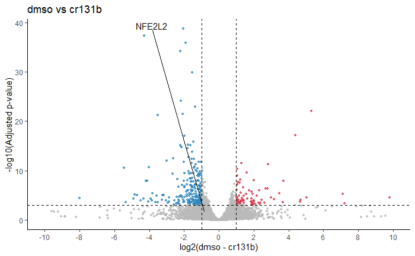

```r
##########################################################################################
datasetFirst = 'dmso'
datasetSecond = 'cr131b'
res = results(dds, contrast = c('treatment', datasetFirst, datasetSecond))
ens.str = substr(rownames(res), 1, 15)
res$symbol = mapIds(org.Hs.eg.db,
                     keys=ens.str,
                     column="SYMBOL",
                     keytype="ENSEMBL",
                     multiVals="first")
resOrdered = res[order(res$pvalue) & !is.na(res$symbol),]

##
saveRDS(as.data.frame(resOrdered),
        paste(baseRepository, '/sequencing20210729_mikePolysomesCr1TbhqOsteo/dataset_deseq2_poly', datasetFirst, '-', datasetSecond, '.rds', sep = ''))
write.csv(as.data.frame(resOrdered),
          file = paste(baseRepository, '/sequencing20210729_mikePolysomesCr1TbhqOsteo/dataset_deseq2_poly', datasetFirst, '-', datasetSecond, '.csv', sep = ''))

##
#resLFC = lfcShrink(dds, coef = paste('treatment_',datasetFirst,'_vs_',datasetSecond, sep = ''), type = "apeglm")
#resLFC
#plotMA(resLFC, ylim = c(-2,2))
rnaExp = as.data.frame(resOrdered)
rnaExp$logPValue = -log10(rnaExp$padj)
#rnaExp$logPValueScaled = ifelse(rnaExp$logPValue > 50, 50, rnaExp$logPValue)
rnaExp$pColors = ifelse(rnaExp$padj <= 0.001 & rnaExp$log2FoldChange >= 1, brewer.pal(8,'Spectral')[1],
                        ifelse(rnaExp$padj <= 0.001 & rnaExp$log2FoldChange <= -1, brewer.pal(8,'Spectral')[8], brewer.pal(11,'RdGy')[8]))
goi = c('NFE2L2')
rnaExp$pText = ifelse(rnaExp$symbol %in% goi, rnaExp$symbol, '')
##
ggplot(rnaExp, aes(log2FoldChange, logPValue)) +
  geom_point(size = 1, color = rnaExp$pColors, alpha = 0.75) +
  labs(x = paste('log2(',datasetFirst,' - ',datasetSecond,')', sep = ''), y = '-log10(Adjusted p-value)', title = paste(datasetFirst,' vs ',datasetSecond, sep='')) +
  geom_text_repel(label = rnaExp$pText, nudge_x = -3, nudge_y = 100) +
  scale_x_continuous(limits = c(-10,10), breaks = seq(-10,10,2)) +
  #scale_y_continuous(limits = c(0,20), breaks = seq(0,20,4)) +
  geom_vline(xintercept = c(-1,1), linetype = 'dashed') +
  geom_hline(yintercept = -log10(0.001), linetype = 'dashed') +
  theme_classic()
##
ggsave(paste(baseRepository, '/sequencing20210729_mikePolysomesCr1TbhqOsteo/scatter_deseq2_poly', datasetFirst, '-', datasetSecond, '.pdf', sep = ''),
       height = 4, width = 4, useDingbats = FALSE)
```